# yfinance

## yfinance

yfinance is a Python api to the [Yahoo! finance](https://finance.yahoo.com) site.

This file resides at `/c/cs458/www/lectures/yfinance.ipynb`

## Everything you need to know about (y)finance

The fundamental law of finance is:

> Buy low, sell high.

But what do you buy? When they think of finance and investing, most people think about the [Dow Jones Industrial Average](https://en.wikipedia.org/wiki/Dow_Jones_Industrial_Average), which comprises 30 large cap US stocks, traded on the New York Stock Exchange (NYSE) and the NASDAQ exchange. (A large cap stock has a market capitalization greater than $10 billion. The market cap is simply the price of a share of stock times the number of shares outstanding.)

By owning a share of stock, you become an owner of the company. You have an **equity** stake in running the company. Major decisions by the company are ratified by a shareholder vote. If you own more than 50% of the stock in a company, you control the company. Stock is also known as **equity** which is just one [asset class](https://en.wikipedia.org/wiki/Asset_classes) in which you might choose to invest. Others include bonds (aka, fixed income or debt), real estate, commodities (e.g., wheat, oil, gold), foreign exchance (currency, like dollars, euros, and yen), derivatives (such as mortgage back securities), and infrastructure (such as roads and airports).

We are going to focus on equity, that is, stocks. The [yfinance](https://pypi.org/project/yfinance/) Python module provides a boatload of information about US stocks and other securities.

## Risk Management

As we learned from Tversky and Kahnemann and behavioral economists, people are risk averse. They don't like losing money. In 1952, Harry Markowitz came up with [Modern Portfolio Theory](https://www.investopedia.com/terms/m/modernportfoliotheory.asp) which, among other things, showed how you can construct a collection or portfolio of stocks to reduce or even minimize the risk of the overall investment. One of Markowitz's insights was that the volatility of a stock's price was a suitable measure of the risk of the investment. You can reduce the overall volatility of a portfolio by investing stocks that are not correlated with each other. Thus, one stock may go up with inflation and another might go down. These movements can offset each other and reduce the portfolio's volatility or risk.

You can fully diversify your portfolio by holding 30 or so stocks - assuming that they are not correlated. One hundred years ago, investors thought they were diversified if they owned 20 different railroad stocks. Go figure.

These days we measure volatility of the entire stock market with the **volatility index** or VIX. It is also known as the **fear index** or **fear gauge**. The higher the VIX, the riskier the market. A rule of thumb is if the VIX is below 14, the market is not risky.

## Portfolio Management: Growth and Value

We assume that everyone wants to avoid losing money. However, there are many different ways to make money. Many stocks pay dividends (usually quarterly) which can provide income to the investor. Usually companies that pay dividends are older and more stable and established, such as banks and utilities. These stocks are often called **value** stocks.

Many stocks do not pay dividends. Instead they reinvest that money in the company to help it grow and expand. These stocks are often called **growth** stocks.

Usually, growth stocks are more volatile than value stocks, which is to say that they are more risky.

These categories are not always clear cut.

Another metric that relates to MPT, is beta, a measure of a stock's volatility relative to the market as a whole. A beta of 1 means that the stock has the same volatility as the entire market (usually the [S and P 500](https://en.wikipedia.org/wiki/S%26P_500). A stable stock will have a beta below 1. A risky stock will have a beta over 1.

## Portfolio Management: Sector

To diversify the risk in a portfolio, you need to buy stocks with different volatility patterns. One common way to do this is by investing in different **sectors** or [industries](https://en.wikipedia.org/wiki/Industry_classification).

Different sectors respond differently to market conditions. In recent years, technology has outperformed sectors like materials or real estate. However, there is no clear pattern over time.

## Security Analysis

Many Wall Street firms, like Morgan Stanley, Goldman Sachs, and Merrill Lynch, employ finance professionals who advise investors which stocks to buy and sell. For example, see a recent Merrill Lynch report on Apple (AAPL). An analysis will usually assign a recommendation of buy, sell, or hold, as well as a price target or price objective - their prediction of the price within the next 12 months. Merrill Lynch assigns Apple a BUY rating and a price objective of 215 from the current price of 172. This is pretty bullish. Note that Merrill Lynch also reports an **ESGMeter** score of **high** for Apple. [ESG](https://en.wikipedia.org/wiki/Environmental,_social_and_corporate_governance) stands for **Environmant, Social, and Governance** which measures a company's commitment to climate change, diversity and related initiatives. The hope is that a company can do well by doing good. According to Merrill Lynch, Apple is one of the good guys.

One focus of a security analyst is to predict future earnings. This figure becomes part of [price/earnings ratio](https://en.wikipedia.org/wiki/Price%E2%80%93earnings_ratio) or simply **p/e ratio**. A low PE suggest that the stock is cheap. A high PE suggests that the stock is expensive.  
However, the PE ratio varies considerably across industries.

Also, there are quantitative models that can value a stock based on future earnings or [discounted cash flows](https://en.wikipedia.org/wiki/Discounted_cash_flow) (DCF). This approach can be used on other assets in addition to stock. A security analyst can project company earnings and then plug those numbers into a DCF model to get a valuation for the company. Using earnings per share, the valuation is the estimated current price of the company. If that price is higher than the market price, then the stock is a BUY. If the valuation price is lower than the market price, the stock is a SELL.

In the homework, you are to write some code that could replace a security analyst.

## Model Portfolios

In addition to analyzing companies, Merrill Lynch also provides sample model portfolios, namely:

- Large Cap Defensive
- Income
- Income and Growth
- Growth
- Mid-Cap
- International

Each of these portfolios comprise 30 or so individual stocks across a dozen industrial sectors. The portfolio specifies the weightings of each holding. Every few weeks or months, Merrill Lynch will publish changes to weightings or holdings to recalibrate the portfolio. See the Research Portfolio Holdings from from January 19, 2022 and February 16, 2022.

Merrill Lynch publishes a primer which explains the investment philosophy and process used to construct these portfolios. The basic premise is that each portfolio has its own risk profile, with Large Cap Defensive being safer than Income, and so forth. Here is last month's Research Portfolio Primer

As a machine learning exercise, you could use the holdings of these portfolios as training data to learn the properties of an income stock versus a growth stock.

## Let's go to Python already

We get started by loading yfinance and some other useful modules. These are available on the zoo. If you do not have them on you personal machine, you can probably install them with

> pip install

```python
import pandas as pd
import yfinance as yf
```

```python
import numpy
numpy.version.version
```

```
'1.21.5'
```

```python
yf.version.version
```

```
'0.1.63'
```

```python
from yahoofinancials import YahooFinancials
```

### load Apple stock prices for the past few years as a data frame

```python
aapl_df = yf.download('AAPL',
                      start='2019-01-01',
                      end='2022-02-11',
                      progress=False,
)
aapl_df.head()
```

| Date | Open | High | Low | Close | Adj Close | Volume |
| --- | --- | --- | --- | --- | --- | --- |
| 2019-01-02 | 38.722500 | 39.712502 | 38.557499 | 39.480000 | 38.277519 | 148158800 |
| 2019-01-03 | 35.994999 | 36.430000 | 35.500000 | 35.547501 | 34.464806 | 365248800 |
| 2019-01-04 | 36.132500 | 37.137501 | 35.950001 | 37.064999 | 35.936081 | 234428400 |
| 2019-01-07 | 37.174999 | 37.207500 | 36.474998 | 36.982498 | 35.856094 | 219111200 |
| 2019-01-08 | 37.389999 | 37.955002 | 37.130001 | 37.687500 | 36.539623 | 164101200 |

```python
aapl_df.tail()
```

| Date | Open | High | Low | Close | Adj Close | Volume |
| --- | --- | --- | --- | --- | --- | --- |
| 2022-02-04 | 171.679993 | 174.100006 | 170.679993 | 172.389999 | 172.389999 | 82391400 |
| 2022-02-07 | 172.860001 | 173.949997 | 170.949997 | 171.660004 | 171.660004 | 77251200 |
| 2022-02-08 | 171.729996 | 175.350006 | 171.429993 | 174.830002 | 174.830002 | 74829200 |
| 2022-02-09 | 176.050003 | 176.649994 | 174.899994 | 176.279999 | 176.279999 | 71285000 |
| 2022-02-10 | 174.139999 | 175.479996 | 171.550003 | 172.119995 | 172.119995 | 90865900 |

### load current Apple data

```python
aapl_df = yf.download('AAPL')
```

```
[*********************100%***********************]  1 of 1 completed
```

### plot Apple stock price for the past 5 years

```python
import matplotlib
```

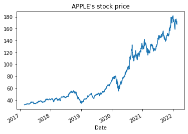

```python
ticker = yf.Ticker('AAPL')
aapl_df = ticker.history(period="5y")
aapl_df['Close'].plot(title="APPLE's stock price")
```

### list the properties available for Apple

```python
dir(ticker)
```

```
['__class__',
 '__delattr__',
 '__dict__',
 '__dir__',
 '__doc__',
 '__eq__',
 '__format__',
 '__ge__',
 '__getattribute__',
 '__gt__',
 '__hash__',
 '__init__',
 '__init_subclass__',
 '__le__',
 '__lt__',
 '__module__',
 '__ne__',
 '__new__',
 '__reduce__',
 '__reduce_ex__',
 '__repr__',
 '__setattr__',
 '__sizeof__',
 '__str__',
 '__subclasshook__',
 '__weakref__',
 '_balancesheet',
 '_base_url',
 '_calendar',
 '_cashflow',
 '_download_options',
 '_earnings',
 '_expirations',
 '_financials',
 '_fundamentals',
 '_get_fundamentals',
 '_history',
 '_info',
 '_institutional_holders',
 '_isin',
```

[output cut: 33 more lines]

```
 'isin',
 'major_holders',
 'mutualfund_holders',
 'option_chain',
 'options',
 'quarterly_balance_sheet',
 'quarterly_balancesheet',
 'quarterly_cashflow',
 'quarterly_earnings',
 'quarterly_financials',
 'recommendations',
 'session',
 'splits',
 'sustainability',
 'ticker']
```

### Print the values for each property from ticker.info

```python
for k,v in ticker.info.items():
    print (k, '\t', v, '\n')
```

```
zip 	 95014

sector 	 Technology

fullTimeEmployees 	 100000

longBusinessSummary 	 Apple Inc. designs, manufactures, and markets smartphones, personal computers, tablets, wearables, and accessories worldwide. It also sells various related services. In addition, the company offers iPhone, a line of smartphones; Mac, a line of personal computers; iPad, a line o…

city 	 Cupertino

phone 	 408 996 1010

state 	 CA

country 	 United States

companyOfficers 	 []

website 	 https://www.apple.com

maxAge 	 1

address1 	 One Apple Park Way

industry 	 Consumer Electronics

ebitdaMargins 	 0.33890998

profitMargins 	 0.26579002

grossMargins 	 0.43019

operatingCashflow 	 112241000448

revenueGrowth 	 0.112

operatingMargins 	 0.309

ebitda 	 128217997312

```

[output cut: 246 more lines]

```
fiftyTwoWeekLow 	 116.21

bid 	 166.48

tradeable 	 False

dividendYield 	 0.0053

bidSize 	 900

dayHigh 	 170.5413

regularMarketPrice 	 167.3

logo_url 	 https://logo.clearbit.com/apple.com
```

### See the analyst recommendations

We see Buy and Neutral, which is like Hold. There is also Outperform, which means that it should do better than its peers, and Overweight, which means that you should hold more Apple as a percentage in your portfolio than Apple's percentage weight in the relevant index.

This brings up an interesting point. If you are a portfolio manager, how are you evaluated? The obvious answer is "How much money did I make for my clients?" However, that is incorrect. Finance professionals know that they will have good years and bad years. They are happy to be rewarded for the good years, but they don't want to be punished for the bad ones. Years ago, a smart portfolio manager proposed that he be measured **relative** to an index or **benchmark**, such as the S&P 500. Thus, if his fund made 15% last year and the S&P made 10%, then the manager outperformed by 5% or 500 basis points. (A basis point is 1/100th of a percentage point.)

If the fund **lost**10% last year but the S&P lost 15%, the manager still outperformed by 5% or 500 basis points. So the rating "Overweight" is relative to the appropriate benchmark index.

That's how they keep score in asset management world.

```python
ticker.recommendations
```

| Date | Firm | To Grade | From Grade | Action |
| --- | --- | --- | --- | --- |
| 2012-02-09 08:17:00 | Canaccord Genuity | Buy |  | main |
| 2012-03-08 07:33:00 | FBN Securities | Outperform |  | main |
| 2012-03-13 06:08:00 | Jefferies | Buy |  | main |
| 2012-03-14 06:13:00 | Morgan Stanley | Overweight |  | main |
| 2012-03-14 08:21:00 | Canaccord Genuity | Buy |  | main |
| ... | ... | ... | ... | ... |
| 2022-01-28 13:01:39 | Deutsche Bank | Buy |  | main |
| 2022-01-28 14:19:01 | New Street Research | Neutral | Sell | up |
| 2022-01-28 15:10:56 | Oppenheimer | Outperform |  | main |
| 2022-01-31 15:44:19 | Credit Suisse | Neutral |  | main |
| 2022-02-15 15:31:58 | Tigress Financial | Strong Buy |  | main |

830 rows × 4 columns

You could evaluate a stock by looking at the analyst recommendations. For example, instead of merely looking for a BUY or SELL recommendation, you could look for a change in recommendation. A move from a SELL to a BUY or HOLD would be a BUY signal. A move from a BUY to a HOLD or SELL would be a SELL signal.

The author had a friend and colleague decades ago who want to start a business based on precisely this premise. He had an MBA from Columbia. He would have done the marketing and sales. I would have implemented the strategy.

I dismissed the idea as being too simple. I was wrong. My colleague is now the President of a major Private Wealth Management firm.

### ESG and Sustainability

There are lots of data here.

```python
ticker.sustainability
```

| 2022-2 | Value |
| --- | --- |
| palmOil | False |
| controversialWeapons | False |
| gambling | False |
| socialScore | 6.86 |
| nuclear | False |
| furLeather | False |
| alcoholic | False |
| gmo | False |
| catholic | False |
| socialPercentile | None |
| peerCount | 55 |
| governanceScore | 8.76 |
| environmentPercentile | None |
| animalTesting | False |
| tobacco | False |
| totalEsg | 16.27 |
| highestControversy | 3 |
| esgPerformance | UNDER_PERF |
| coal | False |
| pesticides | False |
| adult | False |
| percentile | 12.87 |
| peerGroup | Technology Hardware |
| smallArms | False |
| environmentScore | 0.65 |
| governancePercentile | None |
| militaryContract | False |

### Dividends

We can see the recent history of dividend payments.

```python
ticker.actions
```

| Date | Dividends | Stock Splits |
| --- | --- | --- |
| 2017-05-11 | 0.1575 | 0.0 |
| 2017-08-10 | 0.1575 | 0.0 |
| 2017-11-10 | 0.1575 | 0.0 |
| 2018-02-09 | 0.1575 | 0.0 |
| 2018-05-11 | 0.1825 | 0.0 |
| 2018-08-10 | 0.1825 | 0.0 |
| 2018-11-08 | 0.1825 | 0.0 |
| 2019-02-08 | 0.1825 | 0.0 |
| 2019-05-10 | 0.1925 | 0.0 |
| 2019-08-09 | 0.1925 | 0.0 |
| 2019-11-07 | 0.1925 | 0.0 |
| 2020-02-07 | 0.1925 | 0.0 |
| 2020-05-08 | 0.2050 | 0.0 |
| 2020-08-07 | 0.2050 | 0.0 |
| 2020-08-31 | 0.0000 | 4.0 |
| 2020-11-06 | 0.2050 | 0.0 |
| 2021-02-05 | 0.2050 | 0.0 |
| 2021-05-07 | 0.2200 | 0.0 |
| 2021-08-06 | 0.2200 | 0.0 |
| 2021-11-05 | 0.2200 | 0.0 |
| 2022-02-04 | 0.2200 | 0.0 |

```python
ticker.dividends
```

```
Date
2017-05-11    0.1575
2017-08-10    0.1575
2017-11-10    0.1575
2018-02-09    0.1575
2018-05-11    0.1825
2018-08-10    0.1825
2018-11-08    0.1825
2019-02-08    0.1825
2019-05-10    0.1925
2019-08-09    0.1925
2019-11-07    0.1925
2020-02-07    0.1925
2020-05-08    0.2050
2020-08-07    0.2050
2020-11-06    0.2050
2021-02-05    0.2050
2021-05-07    0.2200
2021-08-06    0.2200
2021-11-05    0.2200
2022-02-04    0.2200
Name: Dividends, dtype: float64
```

### ticker.info

There is lots of information the ticker.info dictionary.

The [dividend yield](https://en.wikipedia.org/wiki/Dividend_yield) is the dividend per share divided by the price per share.

```python
ticker.info['dividendYield']
```

```
0.0053
```

**beta** is a measure of the stock's volatility relative to the market. Apple is slightly more volatile.

```python
ticker.info['beta']
```

```
1.187468
```

yfinance has a couple target price data points

```python
list(map(lambda x: ticker.info[x],
         ['targetLowPrice', 'targetMeanPrice','targetMedianPrice','targetHighPrice']))
```

```
[160, 192.56, 195, 215]
```

We can get the sector.

```python
ticker.info['industry']
```

```
'Consumer Electronics'
```

We can find out who owns Apple.

```python
ticker.major_holders
```

|  | 0 | 1 |
| --- | --- | --- |
| 0 | 0.07% | % of Shares Held by All Insider |
| 1 | 59.50% | % of Shares Held by Institutions |
| 2 | 59.54% | % of Float Held by Institutions |
| 3 | 5365 | Number of Institutions Holding Shares |

```python
ticker.institutional_holders
```

|  | Holder | Shares | Date Reported | % Out | Value |
| --- | --- | --- | --- | --- | --- |
| 0 | Vanguard Group, Inc. (The) | 1261261357 | 2021-12-30 | 0.0773 | 223962179162 |
| 1 | Blackrock Inc. | 1019810291 | 2021-12-30 | 0.0625 | 181087713372 |
| 2 | Berkshire Hathaway, Inc | 887135554 | 2021-12-30 | 0.0544 | 157528660323 |
| 3 | State Street Corporation | 633115246 | 2021-12-30 | 0.0388 | 112422274232 |
| 4 | FMR, LLC | 352204129 | 2021-12-30 | 0.0216 | 62540887186 |
| 5 | Geode Capital Management, LLC | 264351901 | 2021-12-30 | 0.0162 | 46940967060 |
| 6 | Price (T.Rowe) Associates Inc | 223148792 | 2021-12-30 | 0.0137 | 39624530995 |
| 7 | Northern Trust Corporation | 190876014 | 2021-12-30 | 0.0117 | 33893853805 |
| 8 | Norges Bank Investment Management | 167580974 | 2020-12-30 | 0.0103 | 22236319440 |
| 9 | Bank Of New York Mellon Corporation | 144695935 | 2021-12-30 | 0.0089 | 25693657177 |

```python
ticker.calendar
```

|  | 0 | 1 |
| --- | --- | --- |
| Earnings Date | 2022-04-26 20:00:00 | 2022-05-02 20:00:00 |
| Earnings Average | 1.43 | 1.43 |
| Earnings Low | 1.34 | 1.34 |
| Earnings High | 1.56 | 1.56 |
| Revenue Average | 93933900000 | 93933900000 |
| Revenue Low | 90042000000 | 90042000000 |
| Revenue High | 100444000000 | 100444000000 |

## YahooFinancials - Apple

```python
yahoo_financials = YahooFinancials('AAPL')
data = yahoo_financials.get_historical_price_data(start_date='2019-01-01',
                                                  end_date='2019-12-31',
                                                  time_interval='weekly')
aapl_df = pd.DataFrame(data['AAPL']['prices'])
aapl_df = aapl_df.drop('date', axis=1).set_index('formatted_date')
aapl_df.head()
```

| formatted_date | high | low | open | close | volume | adjclose |
| --- | --- | --- | --- | --- | --- | --- |
| 2019-01-01 | 39.712502 | 35.500000 | 38.722500 | 36.982498 | 966947200 | 35.856091 |
| 2019-01-08 | 38.632500 | 37.130001 | 37.389999 | 37.500000 | 725470000 | 36.357834 |
| 2019-01-15 | 39.470001 | 37.512501 | 37.567501 | 39.205002 | 491411200 | 38.010902 |
| 2019-01-22 | 39.532501 | 37.924999 | 39.102501 | 39.075001 | 554774800 | 37.884857 |
| 2019-01-29 | 42.915001 | 38.527500 | 39.062500 | 42.812500 | 830400800 | 41.508526 |

```python
dir(yahoo_financials)
```

```
['YAHOO_FINANCIAL_TYPES',
 '_BASE_YAHOO_URL',
 '_INTERVAL_DICT',
 '_MIN_INTERVAL',
 '__class__',
 '__delattr__',
 '__dict__',
 '__dir__',
 '__doc__',
 '__eq__',
 '__format__',
 '__ge__',
 '__getattribute__',
 '__gt__',
 '__hash__',
 '__init__',
 '__init_subclass__',
 '__le__',
 '__lt__',
 '__module__',
 '__ne__',
 '__new__',
 '__reduce__',
 '__reduce_ex__',
 '__repr__',
 '__setattr__',
 '__sizeof__',
 '__str__',
 '__subclasshook__',
 '__weakref__',
 '_build_api_url',
 '_build_historical_url',
 '_cache',
 '_clean_api_data',
 '_clean_earnings_data',
 '_clean_historical_data',
 '_clean_reports',
 '_convert_to_utc',
 '_create_dict_ent',
 '_determine_numeric_value',
```

[output cut: 59 more lines]

```
 'get_stock_earnings_data',
 'get_stock_exchange',
 'get_stock_price_data',
 'get_stock_quote_type_data',
 'get_stock_summary_url',
 'get_stock_tech_data',
 'get_summary_data',
 'get_ten_day_avg_daily_volume',
 'get_three_month_avg_daily_volume',
 'get_time_code',
 'get_total_operating_expense',
 'get_total_revenue',
 'get_yearly_high',
 'get_yearly_low',
 'ticker']
```

```python
for p in dir(yahoo_financials):
    if hasattr(getattr(yahoo_financials,p), '__call__'):
        if p.startswith('get'):
            x = getattr(yahoo_financials, p)()
            print (p, '\t', x)
```

```
get_200day_moving_avg 	 151.1004
get_50day_moving_avg 	 172.4622
get_annual_avg_div_rate 	 0.865
get_annual_avg_div_yield 	 0.00512198
get_beta 	 1.187468
get_book_value 	 71932000000
```

```
---------------------------------------------------------------------------
TypeError                                 Traceback (most recent call last)
/tmp/ipykernel_977215/265645039.py in <module>
      2     if hasattr(getattr(yahoo_financials,p), '__call__'):
      3         if p.startswith('get'):
----> 4             x = getattr(yahoo_financials, p)()
      5             print (p, '\t', x)
      6

TypeError: get_clean_data() missing 2 required positional arguments: 'raw_report_data' and 'report_type'
```

```python
dir(yahoo_financials.get_clean_data.__func__)
```

```
['__annotations__',
 '__call__',
 '__class__',
 '__closure__',
 '__code__',
 '__defaults__',
 '__delattr__',
 '__dict__',
 '__dir__',
 '__doc__',
 '__eq__',
 '__format__',
 '__ge__',
 '__get__',
 '__getattribute__',
 '__globals__',
 '__gt__',
 '__hash__',
 '__init__',
 '__init_subclass__',
 '__kwdefaults__',
 '__le__',
 '__lt__',
 '__module__',
 '__name__',
 '__ne__',
 '__new__',
 '__qualname__',
 '__reduce__',
 '__reduce_ex__',
 '__repr__',
 '__setattr__',
 '__sizeof__',
 '__str__',
 '__subclasshook__']
```

```python
hasattr(yahoo_financials.get_beta, '__call__')
```

```
True
```

```python
for p in dir(yahoo_financials):
    print (p, '\t', getattr(yahoo_financials, p), '\n')
```

```
YAHOO_FINANCIAL_TYPES 	 {'income': ['financials', 'incomeStatementHistory', 'incomeStatementHistoryQuarterly'], 'balance': ['balance-sheet', 'balanceSheetHistory', 'balanceSheetHistoryQuarterly', 'balanceSheetStatements'], 'cash': ['cash-flow', 'cashflowStatementHistory', 'cashflowStatementHistoryQu…

_BASE_YAHOO_URL 	 https://finance.yahoo.com/quote/

_INTERVAL_DICT 	 {'daily': '1d', 'weekly': '1wk', 'monthly': '1mo'}

_MIN_INTERVAL 	 7

__class__ 	 <class 'yahoofinancials.YahooFinancials'>

__delattr__ 	 <method-wrapper '__delattr__' of YahooFinancials object at 0x7ffa882c6fd0>

__dict__ 	 {'ticker': 'AAPL', '_cache': {'https://finance.yahoo.com/quote/AAPL/financials?p=AAPL': {'context': {'dispatcher': {'stores': {'PageStore': {'currentPageName': 'quote', 'currentEvent': {'eventName': 'NEW_PAGE_SUCCESS'}, 'currentRenderTargetId': 'default', 'pagesConfigRaw': {'base': {'quot…

__dir__ 	 <built-in method __dir__ of YahooFinancials object at 0x7ffa882c6fd0>

__doc__ 	 None

__eq__ 	 <method-wrapper '__eq__' of YahooFinancials object at 0x7ffa882c6fd0>

__format__ 	 <built-in method __format__ of YahooFinancials object at 0x7ffa882c6fd0>

__ge__ 	 <method-wrapper '__ge__' of YahooFinancials object at 0x7ffa882c6fd0>

__getattribute__ 	 <method-wrapper '__getattribute__' of YahooFinancials object at 0x7ffa882c6fd0>

__gt__ 	 <method-wrapper '__gt__' of YahooFinancials object at 0x7ffa882c6fd0>

__hash__ 	 <method-wrapper '__hash__' of YahooFinancials object at 0x7ffa882c6fd0>

__init__ 	 <bound method YahooFinanceETL.__init__ of <yahoofinancials.YahooFinancials object at 0x7ffa882c6fd0>>

__init_subclass__ 	 <built-in method __init_subclass__ of type object at 0x5612ac693de0>

__le__ 	 <method-wrapper '__le__' of YahooFinancials object at 0x7ffa882c6fd0>

__lt__ 	 <method-wrapper '__lt__' of YahooFinancials object at 0x7ffa882c6fd0>

__module__ 	 yahoofinancials

```

[output cut: 172 more lines]

```
get_ten_day_avg_daily_volume 	 <bound method YahooFinancials.get_ten_day_avg_daily_volume of <yahoofinancials.YahooFinancials object at 0x7ffa882c6fd0>>

get_three_month_avg_daily_volume 	 <bound method YahooFinancials.get_three_month_avg_daily_volume of <yahoofinancials.YahooFinancials object at 0x7ffa882c6fd0>>

get_time_code 	 <bound method YahooFinanceETL.get_time_code of <yahoofinancials.YahooFinancials object at 0x7ffa882c6fd0>>

get_total_operating_expense 	 <bound method YahooFinancials.get_total_operating_expense of <yahoofinancials.YahooFinancials object at 0x7ffa882c6fd0>>

get_total_revenue 	 <bound method YahooFinancials.get_total_revenue of <yahoofinancials.YahooFinancials object at 0x7ffa882c6fd0>>

get_yearly_high 	 <bound method YahooFinancials.get_yearly_high of <yahoofinancials.YahooFinancials object at 0x7ffa882c6fd0>>

get_yearly_low 	 <bound method YahooFinancials.get_yearly_low of <yahoofinancials.YahooFinancials object at 0x7ffa882c6fd0>>

ticker 	 AAPL
```

```python
p = yahoo_financials.get_beta
```

```python
p()
```

```
1.187468
```

## YahooFinancials - Bitcoin

```python
yahoo_financials = YahooFinancials('BTC-USD')
data=yahoo_financials.get_historical_price_data("2019-07-10", "2021-05-30", "monthly")
btc_df = pd.DataFrame(data['BTC-USD']['prices'])
btc_df = btc_df.drop('date', axis=1).set_index('formatted_date')
btc_df.head()
```

| formatted_date | high | low | open | close | volume | adjclose |
| --- | --- | --- | --- | --- | --- | --- |
| 2019-08-01 | 12273.821289 | 9421.629883 | 10077.442383 | 9630.664062 | 533984971734 | 9630.664062 |
| 2019-09-01 | 10898.761719 | 7830.758789 | 9630.592773 | 8293.868164 | 480544963230 | 8293.868164 |
| 2019-10-01 | 10021.744141 | 7446.988770 | 8299.720703 | 9199.584961 | 595205134748 | 9199.584961 |
| 2019-11-01 | 9505.051758 | 6617.166992 | 9193.992188 | 7569.629883 | 676919523650 | 7569.629883 |
| 2019-12-01 | 7743.431641 | 6540.049316 | 7571.616211 | 7193.599121 | 633790373416 | 7193.599121 |

## The Standard and Poors 500 Index

When we speak of "The Market" or a beta relative to the market, we are usually referring to the S and P 500. It has its own ticker: '^GSPC'

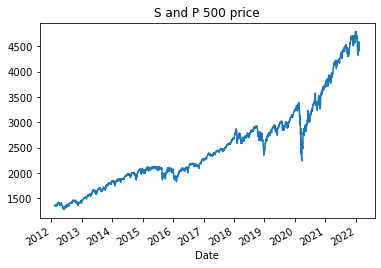

```python
ticker = yf.Ticker('^GSPC')
sandp_df = ticker.history(period="10y")
sandp_df['Close'].plot(title="S and P 500 price")
```

```python
for k,v in ticker.info.items():
    print (k, '\t', v, '\n')
```

```
exchange 	 SNP

shortName 	 S&P 500

exchangeTimezoneName 	 America/New_York

exchangeTimezoneShortName 	 EST

isEsgPopulated 	 False

gmtOffSetMilliseconds 	 -18000000

quoteType 	 INDEX

symbol 	 ^GSPC

messageBoardId 	 finmb_INDEXGSPC

market 	 us_market

previousClose 	 4504.08

regularMarketOpen 	 4506.27

twoHundredDayAverage 	 4452.035

trailingAnnualDividendYield 	 None

payoutRatio 	 None

volume24Hr 	 None

regularMarketDayHigh 	 4526.33

navPrice 	 None

averageDailyVolume10Day 	 3796530000

totalAssets 	 None

```

[output cut: 72 more lines]

```
fiftyTwoWeekLow 	 3723.34

bid 	 4362.32

tradeable 	 False

dividendYield 	 None

bidSize 	 0

dayHigh 	 4526.33

regularMarketPrice 	 4418.64

logo_url
```